# OOPS_6_Polymorphism

#### Duck Typying Philosophy of Python:

In Python we cannot specify the type explicitly. Based on provided value at runtime the type will be considered automatically. Hence Python is considered as Dynamically Typed Programming Language.  
def f1(obj):  
obj.talk()

```python
class Duck():
    def talk(self):
        print('Quack.. Quack..')
class Dog():
    def talk(self):
        print('Bow.. Bow.')
class Cat():
    def talk(self):
        print('Moew.. Moew..')
class Goat():
    def talk(self):
        print('Myaah.. Myaah..')
def f1(obj):
    obj.talk()

l = [Duck(),Dog(),Cat(),Goat()]

for obj in l:
    f1(obj)
```

```
Quack.. Quack..
Bow.. Bow.
Moew.. Moew..
Myaah.. Myaah..
```

```python
class Duck:
    def talk(self):
        print('Quack.. Quack..')

class Human:
    def talk(self):
        print('Hello Hi...')

class Dog:
    def bark(self):
        print('Bow Bow..')

def  f1(obj):
    if hasattr(obj,'talk'):
        obj.talk()
    elif hasattr(obj,'bark'):
        obj.bark()

d=Duck()
f1(d)

h=Human()
f1(h)

d=Dog()
f1(d)
```

```
Quack.. Quack..
Hello Hi...
Bow Bow..
```

#### Polymorphism means "Many Forms"

1. Overloading  
   i) Operator Overloading  
   ii) Constructor Overloading  
   iii) Method Overloading
2. Overriding  
   i) Method overriding  
   ii) Constructor overriding

#### Operator Overloading

We can use the same operator for multiple purposes, which is nothing but operator overloading.

```python
10+20
```

```
30
```

```python
'10'*3
```

```
'101010'
```

```python
#Demo program to use + operator for our class objects:
class Book():
    def __init__(self,pages):
        self.pages = pages
b1 = Book(100)
b2 = Book(200)
print(b1+b2)
```

```
---------------------------------------------------------------------------
TypeError                                 Traceback (most recent call last)
<ipython-input-11-36e5d7cf9d20> in <module>
      5 b1 = Book(100)
      6 b2 = Book(200)
----> 7 print(b1+b2)

TypeError: unsupported operand type(s) for +: 'Book' and 'Book'
```

Mathematical Operator

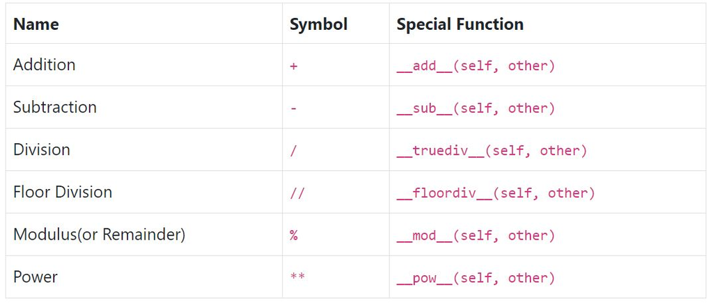

Assignment Operator

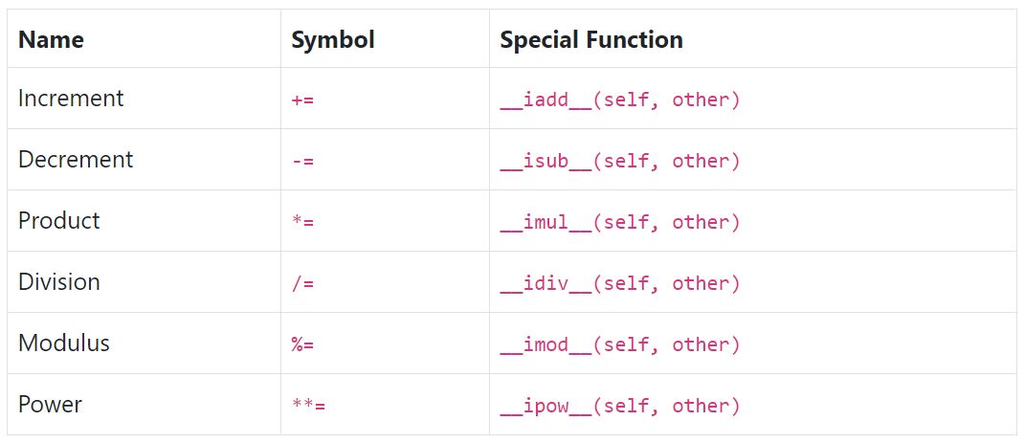

Relational Operator

[figure not shown]

```python
class Book():
    def __init__(self,pages):
        self.pages = pages
    def __add__(self,other):
        return self.pages + other.pages

b1 = Book(100)
b2 = Book(200)

print('The Total Number of Pages:', b1+b2)
```

```
The Total Number of Pages: 300
```

```python
class Student():
    def __init__(self,name,marks):
        self.name = name
        self.marks = marks
    def __gt__(self,other):
        return self.marks > other.marks
    def __le__(self,other):
        return self.marks <= other.marks

s1 = Student('Durga', 100)
s2 = Student('Ravi', 200)
print('s1>s2=',s1>s2)
print('s1<s2=',s1<s2)
print('s1<=s2=',s1<=s2)
print('s1>=s2=',s1>=s2)
```

```
s1>s2= False
s1<s2= True
s1<=s2= True
s1>=s2= False
```

#### Method Overloading

- If 2 methods having same name but different type of arguments then those methods are said to be overloaded methods.
- But in Python Method overloading is not possible.
- If we are trying to declare multiple methods with same name and different number of arguments then Python will always consider only last method.

```python
class Test():
    def m1(self):
        print('no-arg method')
    def m1(self,a):
        print('one-arg method')
    def m1(self,a,b):
        print('Two-arg method')

t = Test()
t.m1(2) #python will consider only last method
```

```
---------------------------------------------------------------------------
TypeError                                 Traceback (most recent call last)
<ipython-input-7-9653f1e2dba4> in <module>
      8
      9 t = Test()
---> 10 t.m1(2)

TypeError: m1() missing 1 required positional argument: 'b'
```

```python
#Demo Program with Default Arguments:
"""
If method with variable number of arguments required then we can
handle with default arguments or with variable number of argument methods.
"""
class Test:
    def sum(self,a=None,b=None,c=None):
        if a!=None and b!= None and c!= None:
            print('The Sum of 3 Numbers:',a+b+c)
        elif a!=None and b!= None:
            print('The Sum of 2 Numbers:',a+b)
        else:
            print('Please provide 2 or 3 arguments')
t=Test()
t.sum(10,20)
t.sum(10,20,30)
t.sum(10)
```

```
The Sum of 2 Numbers: 30
The Sum of 3 Numbers: 60
Please provide 2 or 3 arguments
```

```python
#Demo Program with variable number of Arguments:
class Test():
    def sum(self,*a):
        Total = 0
        for x in a:
            Total = Total + x
        print('The Sum:', Total)

t = Test()
t.sum(10,20)
t.sum(10,20,30)
t.sum(10)
t.sum()
```

```
The Sum: 30
The Sum: 60
The Sum: 10
The Sum: 0
```

#### Constructor Overloading

- Constructor overloading is not possible in Python.
- If we define multiple constructors then the last constructor will be considered.

```python
class Test():
    def __init__(self):
        print('no-arg method')
    def __init__(self,a):
        print('one-arg method')
    def __init__(self,a,b):
        print('Two-arg method')

t = Test(1,2)
```

```
Two-arg method
```

```python
#Demo Program with Default Arguments:
"""
If method with variable number of arguments required then we can
handle with default arguments or with variable number of argument methods.
"""
class Test():
    def __init__(self,a=None,b=None,c=None):
          print('Constructor with 0|1|2|3 number of arguments')
t1=Test()
t2=Test(10,20)
t3=Test(10,20,30)
```

```
Constructor with 0|1|2|3 number of arguments
Constructor with 0|1|2|3 number of arguments
Constructor with 0|1|2|3 number of arguments
```

```python
#Demo Program with variable number of Arguments:
class Test():
    def __init__(self,*a):
        print('Constructor with variable number of arguments')

t1=Test()
t2=Test(10,20)
t3=Test(10,20,30)
```

```
Constructor with variable number of arguments
Constructor with variable number of arguments
Constructor with variable number of arguments
```

#### Method Overriding

What ever members available in the parent class are bydefault available to the child class through inheritance. If the child class not satisfied with parent class implementation then child class is allowed to redefine that method in the child class based on its requirement. This concept is called overriding.

```python
class P():
    def property(self):
        print('Gold + Land + Cash + Power')
    def marry(self):
        print('Appalamma')
class C(P):
    def marry(self):
        print('Katrina Kaif')
c = C()
c.marry()
```

```
Katrina Kaif
```

```python
class P():
    def property(self):
        print('Gold + Land + Cash + Power')
    def marry(self):
        print('Appalamma')
class C(P):
    def marry(self):
        super().marry()
        print('Katrina Kaif')
c = C()
c.marry()
c.property()
```

```
Appalamma
Katrina Kaif
Gold + Land + Cash + Power
```

#### Constructor Overriding:

```python
class P():
    def __init__(self):
        print('Parent Constructor')
class C(P):
    def __init__(self):
        print('Child Constructor')

c=C()
```

```
Child Constructor
```

```python
class Person:
    def __init__(self,name,age):
        self.name = name
        self.age = age
class Employee(Person):
    def __init__(self,name,age,eno,esal):
        super().__init__(name,age)
        self.eno = eno
        self.esal = esal
    def display(self):
        print('Employee Name:', self.name)
        print('Employee Age:', self.age)
        print('Employee Number:', self.eno)
        print('Employee Salary:', self.esal)

e1 = Employee('Durga', 48,872425,26000)
e1.display()
e1 = Employee('Sunny', 50,872454,86000)
e1.display()
```

```
Employee Name: Durga
Employee Age: 48
Employee Number: 872425
Employee Salary: 26000
Employee Name: Sunny
Employee Age: 50
Employee Number: 872454
Employee Salary: 86000
```